# Data Product HW2: PCA Image Compression

Vijay Avala

2026-09-30

# Check out my Shiny App Here: [Shiny App](https://ihr6pg-vijay-avala.shinyapps.io/PCA-Image-Compression/)

# Key Idea: PCA for Image Compression

Suppose we have data in a matrix $X$ which has $n$ rows and $p$ columns. If we let $V = X'X$ (i.e. the cross product of $X$), then recall that the eigendecomposition of $V$ is

$$V = U \Lambda U'$$

where $U$ is a $p \times p$ orthonormal matrix of eigenvectors and $\Lambda$ is a $p \times p$ diagonal matrix of eigenvalues.

We can write the original data matrix $X$ using the following identity,

$$X = X U U'$$

because $U$ is orthonormal and $UU' = I$. If we let $Z = XU$ then we can rewrite this identity as

$$X = Z U'$$

where $Z$ is the $n \times p$ matrix of principal component scores. If $z_1$ is the first column of $Z$ (i.e. the first PC score) and $u_1$ is the first column of $U$ (i.e. the first eigenvector), then we can define the rank 1 approximation of $X$ as the outer product,

$$X_{(1)} = z_1 u_1'$$

which is the outer product of the vectors $z_1$ and $u_1$. Following this pattern, the rank 2 approximation of $X$ is

$$X_{(2)} = z_1 u_1' + z_2
u_2'$$

by adding in the outer product of the second PC score and eigenvector. Finally, the rank $p$ approximation of $X$ is simply

$$X_{(p)} = z_1 u_1' + z_2 u_2' +
\cdots + z_p u_p'$$

which is also equal to the original $X$ matrix.

Each of the rank $k$ approximations where $k < p$ can be thought of as a compressed version of the original matrix $X$. We can tune the amount of compression we achieve by tuning the rank of the approximation. The rank 1 approximation is the smallest version of the image we can generate using this approach and it requires $n + p$ numbers (as opposed to $n \times p$ numbers for the original matrix).

The error induced by the rank $k$ approximation can be measured by the Frobenius norm of the difference $X - X_{(k)}$, which is

$$\text{Error}(k) = \| X - X_{(k)} \| =
\sqrt{\text{trace}\left( (X - X_{(k)})' (X - X_{(k)})
\right)}.$$

(See the `norm()` function in R for calculations.)

# Write function to create approximation of matrix x

```r
# Write a function in R that takes as input an image (as an n x p matrix) and a value k and
# returns
# 1. The rank k approximation to the image using principal components analysis;
# 2. The error of the rank k approximation according to the Frobenius norm.

compression_function <- function(x, k = 1){
  #In R, the eigen() function computes the eigendecomposition of a matrix and the prcomp() function does PCA directly on a matrix

  V <- t(x) %*% x

  r <- eigen(V)
  U <- r$vectors
  # lam <- diag(r$values)
  Z <- prcomp(x, center = FALSE)
  rotation_prcomp <- Z$rotation
  Z <- Z$x

  # Flip sign of each eigenvector in U to match prcomp's rotation matrix
  for (i in 1:ncol(U)) {
    if (sum(U[,i] * rotation_prcomp[,i]) < 0) {
      U[,i] <- -U[,i]
    }
  }

  #make approximated x matrix
  approximation <- Z[,1] %*% t(U[,1])
  if(k>1){
    for (i in 2:k) {
      approximation <- approximation + Z[,i] %*% t(U[,i])
    }
  }


  return(list("approximation" = approximation, "error" = norm(x-approximation, type = "F"), "U" = U, "Z" = Z))

}
```

# Image 1

## **Original Image:**

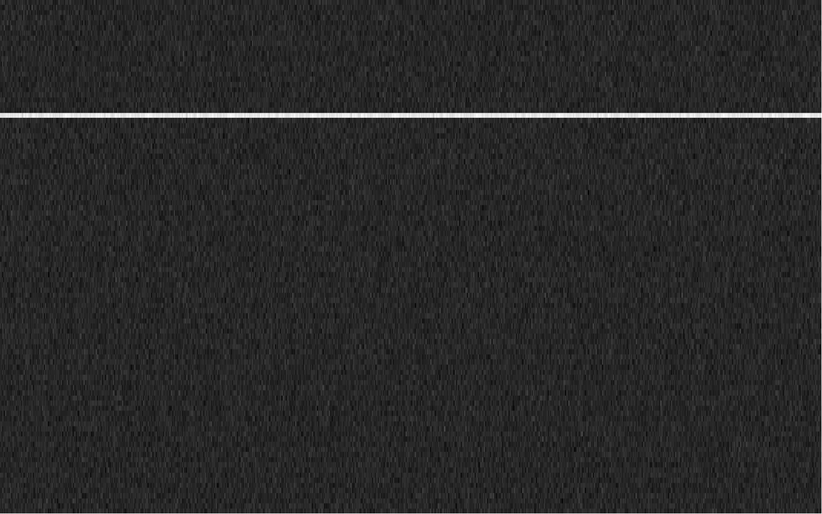

## **Compressed Image:**

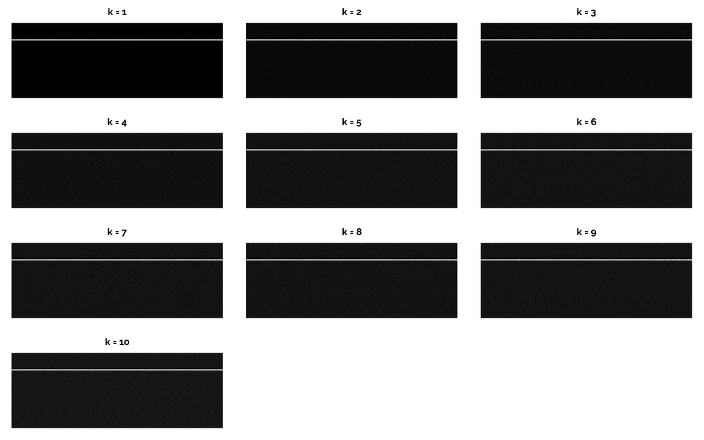

## **What K-Value is good?**

*I feel that* *k=4* *is a reasonable k value for this image since that is where the background starts to have the noise that the original image’s background had.*

## **Error Plot**

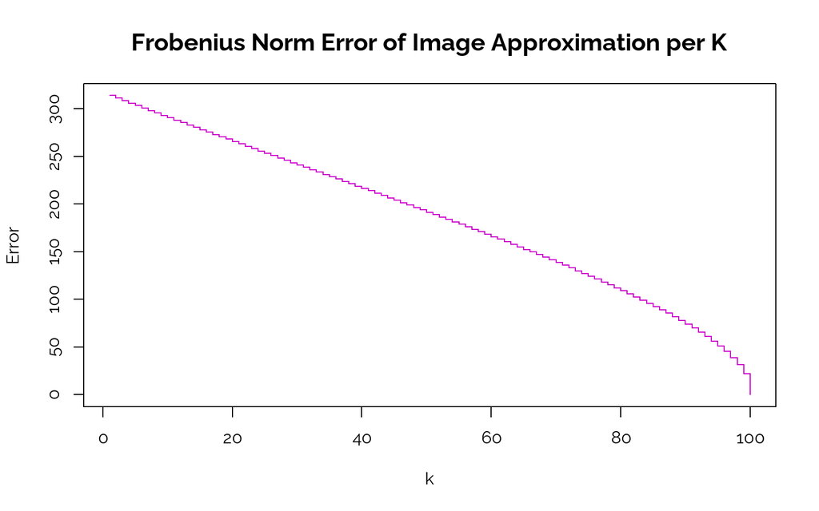

*Note how the error approaches 0 as k increases until it reaches 0 at k=100 because, at that point, we have the original matrix since* $X_{(p)} = z_1 u_1' + z_2 u_2' + \cdots + z_p u_p' = X$.

## **First Eigenvector**

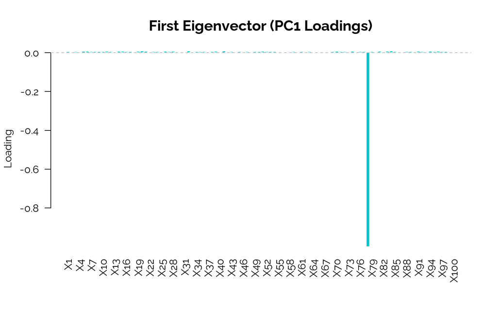

*The first eigenvector contains values the indicate how much each column of the original image contributes to the first principal component (PC1 Loadings). We can see that the 78th column had a large magnitude and so it contributed heavily to PC1.*

## **First PC**

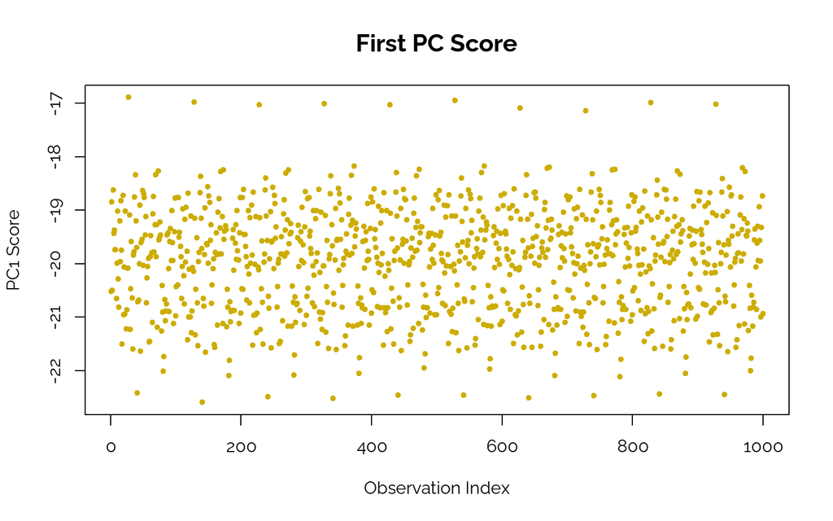

# Image 2

## **Original Image:**

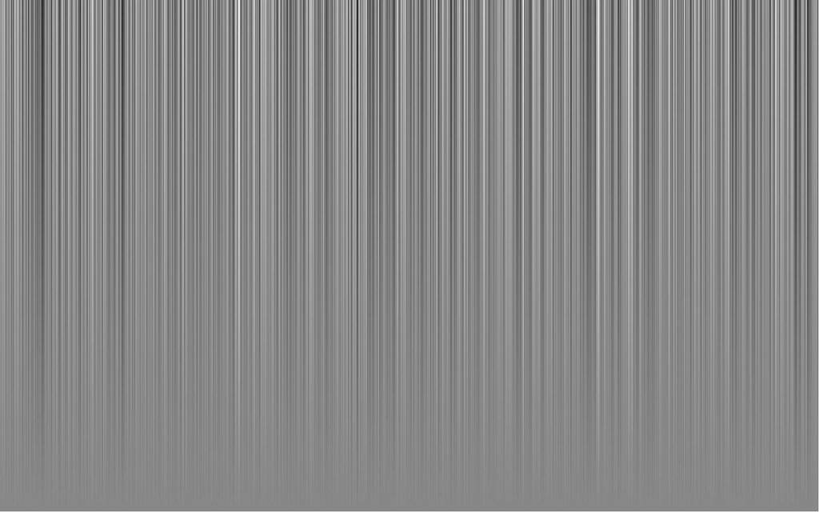

## **Compressed Image:**

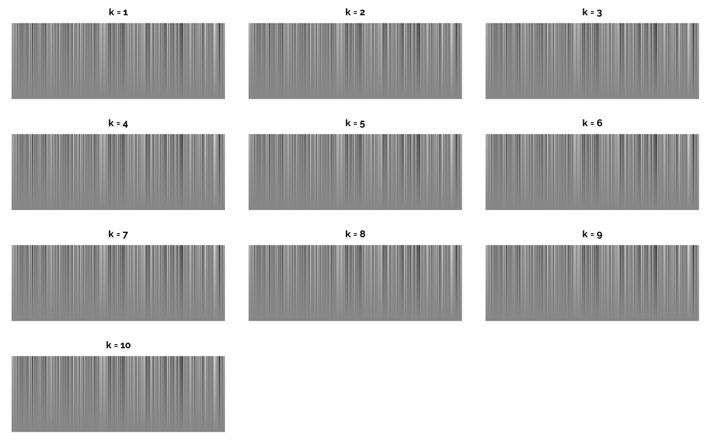

## **What K-Value is good?**

*I feel that* *k=1* *is a reasonable k value for this image since the error drops to nearly 0 at k=2 (look at error plot).*

## **Error Plot**

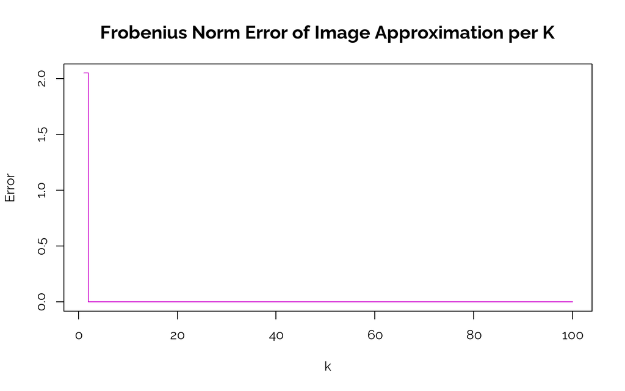

## **First Eigenvector**

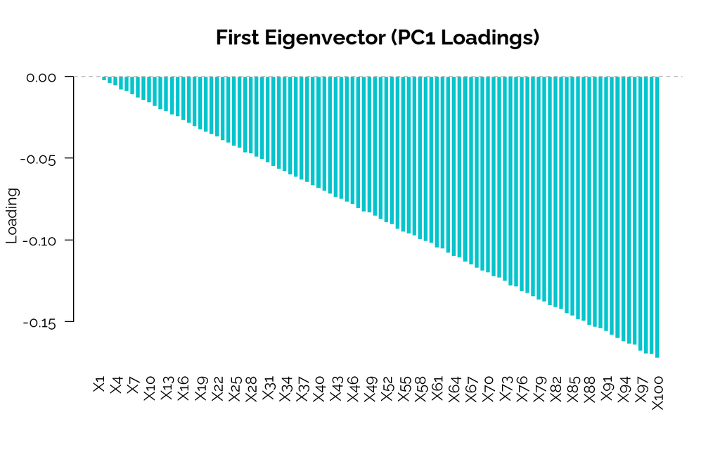

*The first eigenvector contains values the indicate how much each column of the original image contributes to the first principal component (PC1 Loadings). We can see that for this image, each column contributes more to PC1 than the previous column.*

## **First PC**

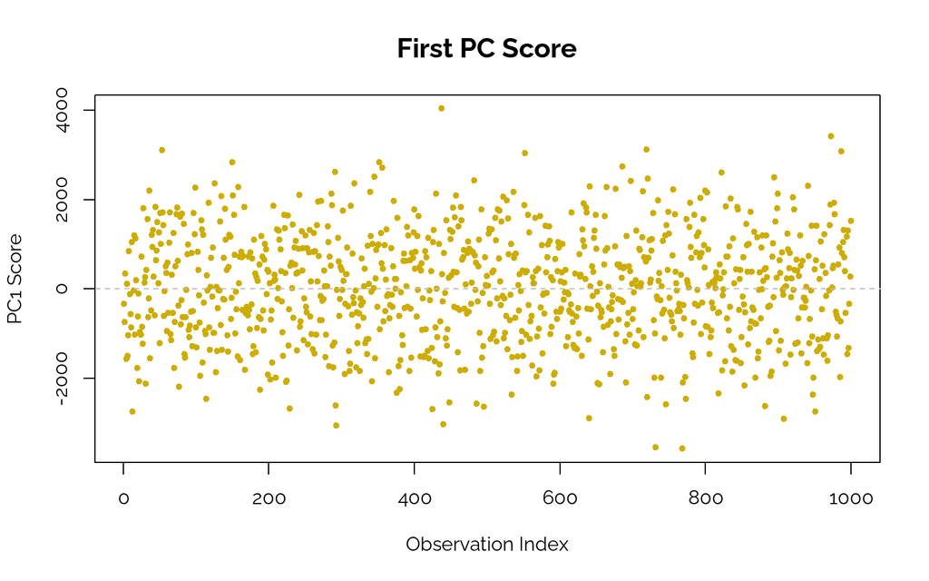

*PC1 scores capture the direction of greatest variance in the original data. The scores are uniformly random around 0, which makes sense since the coloring of each column in the image seems random and there seems to be as many bright lines as dark lines.*

# Image 3

## **Original Image:**

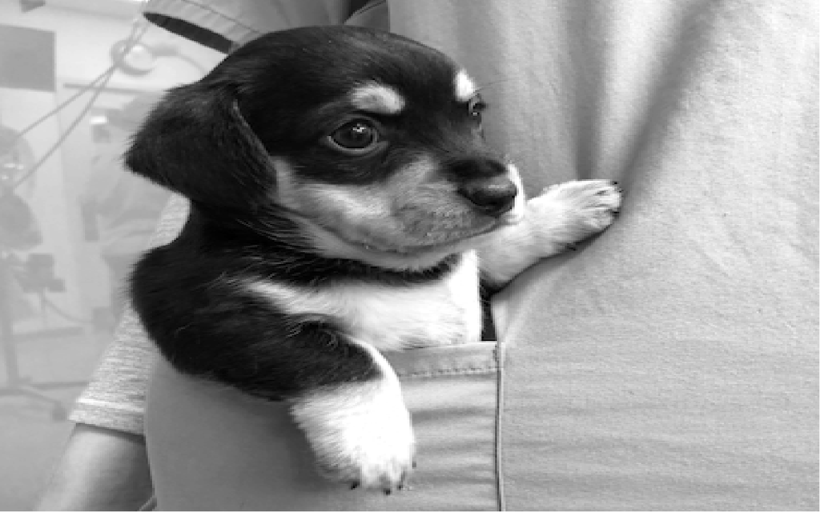

## **Compressed Image:**

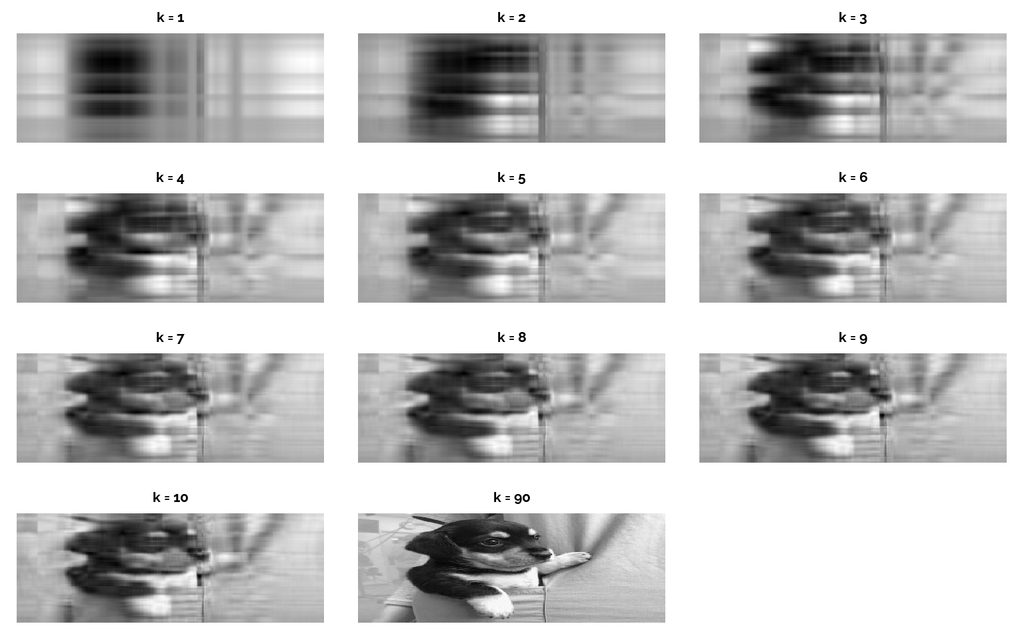

## **What K-Value is good?**

*I feel that* *k=90* *is a reasonable k value for this image since that is where we can start to see the individual white fur details that the original image has.*

**Error Plot**

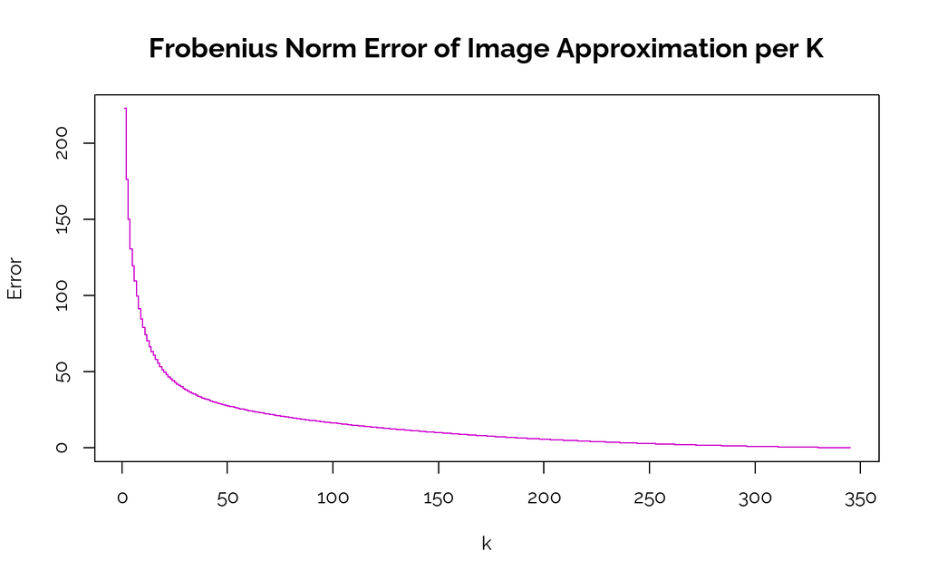

## **First Eigenvector**

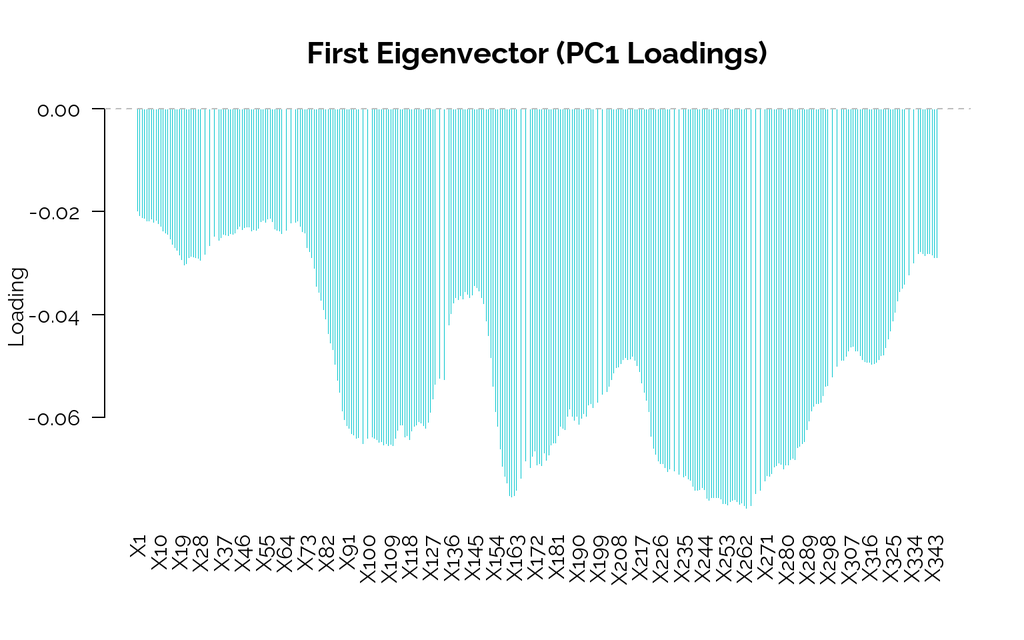

*The first eigenvector contains values the indicate how much each column of the original image contributes to the first principal component (PC1 Loadings). We can see that there are broad regions which seem to have large effects on PC1, so perhaps those column intervals correspond to columns that are depicting detailed features in the image (ex. the background, paws, face, etc.).*

## **First PC**

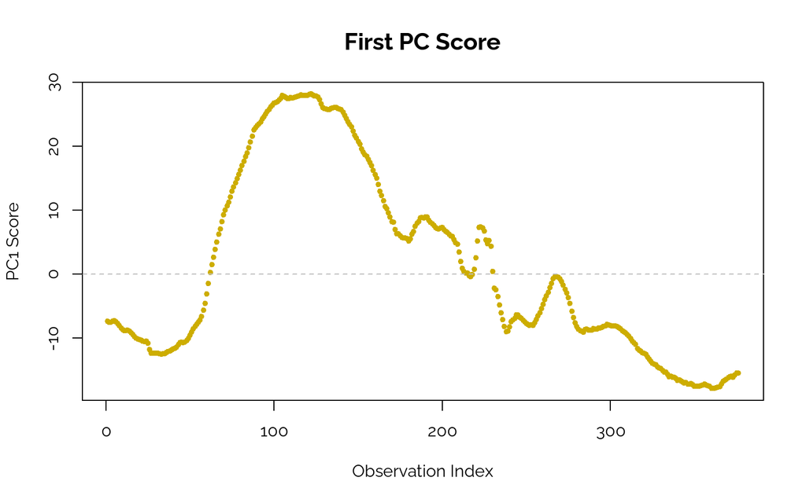

*PC1 scores capture the direction of greatest variance in the original data. The PC scores are high in the 75-175 columns which could correspond to the puppy’s contrast against the shirt/background (which would make sense as it is mostly dark pixels against the brighter shirt and background).*

# Image 4

## **Original Image:**

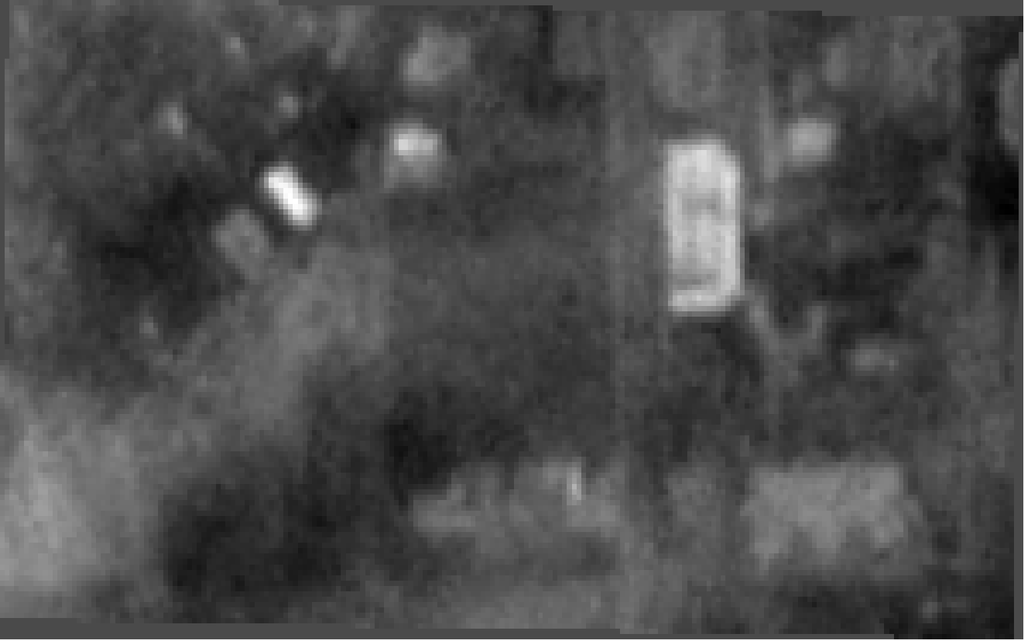

## **Compressed Image:**

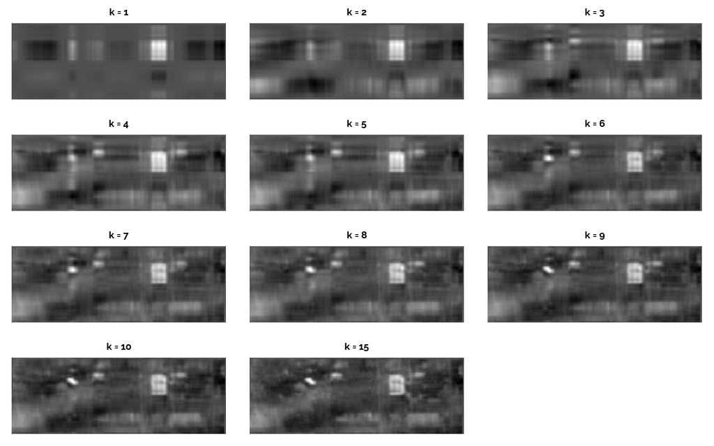

## **What K-Value is good?**

*I feel that* *k=15* *is a reasonable k value for this image since that is where we start to see the grain of the original photo so we know we aren’t missing any meaningful details.*

## **Error Plot**

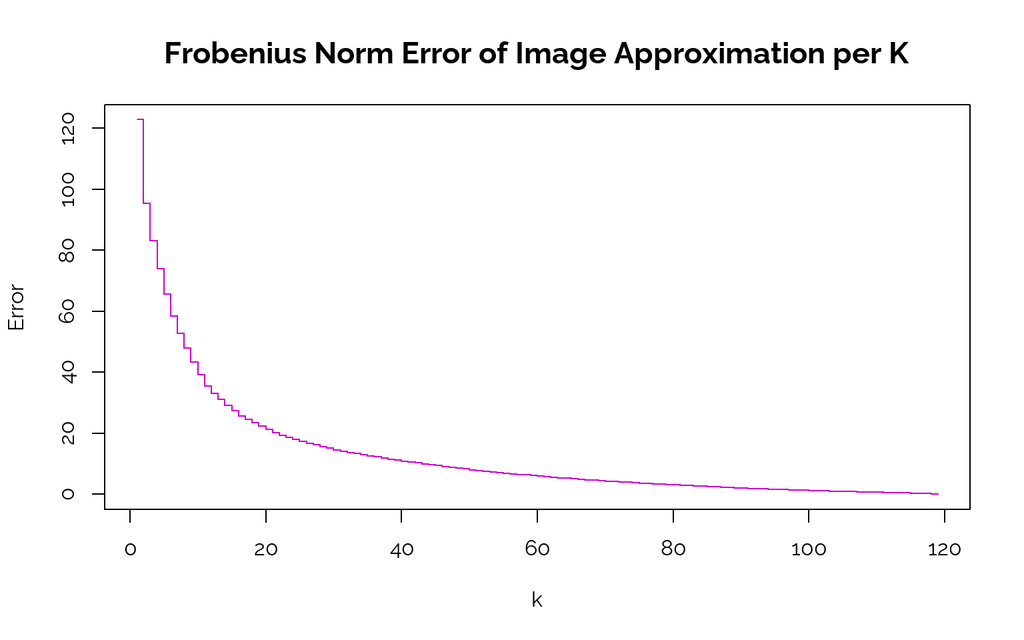

## **First Eigenvector**

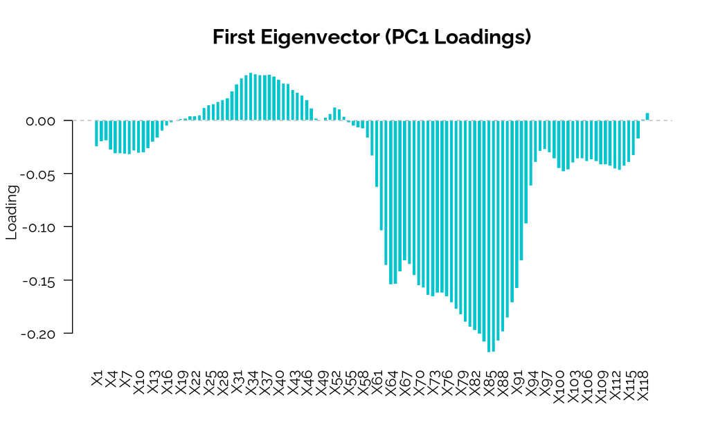

*The first eigenvector contains values the indicate how much each column of the original image contributes to the first principal component (PC1 Loadings). We can see that there are broad regions which seem to have large effects on PC1, so perhaps those column intervals correspond to columns that are depicting detailed features in the image (ex. the different buildings against the dark terrain).*

## **First PC**

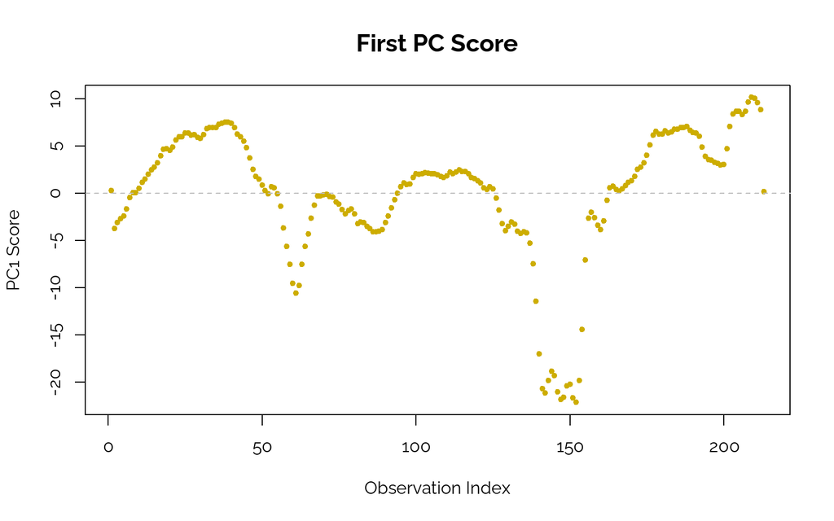

*PC1 scores capture the direction of greatest variance in the original data. There seems to be some strong negative scores around 150 which could correspond to the bright large building in the image that would be around that position column-wise.*